# Lab 09 Replication Notebook

Christopher Prener, Ph.D.

(March 29, 2018)

## Introduction

This is the replication notebook for Lab 09 from the course SOC 4650/5650: Introduction to GISc.

## Load Dependencies

The following code loads the package dependencies for our analysis:

```r
# tidyverse packages
library(dplyr)   # data wrangling
library(ggplot2) # plot data
library(readr)   # work with csv files
# other packages
library(here)    # manage file paths
library(leaflet) # interactive mapping
library(sf)      # spatial data tools
```

## Load Data

We’ll use data distributed with the `lecture-10` repository:

```r
capitals <- read_csv(here("data", "stateCapitals.csv"))
counties <- st_read(here("data", "US_BOUNDARY_Counties", "US_BOUNDARY_Counties.shp"),
                    stringsAsFactors = FALSE)
noins <- read_csv(here("data", "US_HEALTH_noIns.csv"))
```

## Projecting State Capitals

The state capitals data contain four variables and a row for each of the 50 U.S. states:

```r
glimpse(capitals)
```

```
Observations: 50
Variables: 4
$ name        <chr> "Alabama", "Alaska", "Arizona", "Arkansas", "California", "Colorado", "Connecticut", "D...
$ description <chr> "Montgomery", "Juneau", "Phoenix", "Little Rock", "Sacramento", "Denver", "Hartford", "...
$ latitude    <dbl> 32.37772, 58.30160, 33.44814, 34.74661, 38.57667, 39.73923, 41.76405, 39.15731, 21.3074...
$ longitude   <dbl> -86.30057, -134.42021, -112.09696, -92.28899, -121.49363, -104.98486, -72.68220, -75.51...
```

The `longitude` data is always the `x` variable and the `latitude` data is always the `y` variable. To project based on these two variables, we’ll use the `st_as_sf()` function and assign the output to a new object:

```r
capitals_sf <- st_as_sf(capitals, coords = c(x = "longitude", y = "latitude"), crs = 4326)
```

Note that we used the `WGS 1984` coordinate system initially so that we don’t get errors from `leaflet`. We’ll use `leaflet` to test our projected point data and make sure that the markers appear over state capitals:

```r
leaflet() %>%
  addTiles() %>%
  addMarkers(data = capitals)
```

```
Assuming 'longitude' and 'latitude' are longitude and latitude, respectively
```

[interactive chart not shown]

With our data visually verified, we can go ahead and (1) re-project them from `WGS 1984` to `NAD 1983` and then (2) export them to our project’s `data/` directory.

```r
capitals_sf %>%
  st_transform(crs = 4269) %>%
  st_write(here("data", "US_CAPITALS", "US_CAPITALS.shp"), delete_dsn = TRUE)
```

```
Field names abbreviated for ESRI Shapefile driver
```

```
Deleting source `/Users/chris/GitHub/SOC5650/LectureRepos/lecture-10/assignments/lab-09/lab-09-replication/data/US_CAPITALS/US_CAPITALS.shp' using driver `ESRI Shapefile'
Writing layer `US_CAPITALS' to data source `/Users/chris/GitHub/SOC5650/LectureRepos/lecture-10/assignments/lab-09/lab-09-replication/data/US_CAPITALS/US_CAPITALS.shp' using driver `ESRI Shapefile'
features:       50
fields:         2
geometry type:  Point
```

Notice how we can pipe these functions - the `sf` package allows us to use `%>%` to pass `sf` object names through functions. Since we are using a function that writes to our hard disk, we do not need to include an outgoing assignment to an object at the end of the pipe.

## Create Counties Shapefile

We loaded data about county boundaries and un-insurance rates earlier in the notebook. It is time to join these data so that we have a combined shapefile. First, we have to check to make sure we have compatible ID variables:

```r
glimpse(counties)
```

```
Observations: 3,220
Variables: 6
$ GEOID    <dbl> 20175, 28141, 36101, 50013, 5065, 17123, 19011, 27161, 39109, 46073, 48173, 51079, 72087, ...
$ STATEFP  <chr> "20", "28", "36", "50", "05", "17", "19", "27", "39", "46", "48", "51", "72", "72", "08", ...
$ COUNTYFP <chr> "175", "141", "101", "013", "065", "123", "011", "161", "109", "073", "173", "079", "087",...
$ NAME     <chr> "Seward", "Tishomingo", "Steuben", "Grand Isle", "Izard", "Marshall", "Benton", "Waseca", ...
$ ALAND    <chr> "1655865960", "1098939230", "3601566799", "211894597", "1503685418", "1001787871", "185511...
$ geometry <sf_geometry [degree]> MULTIPOLYGON (((-101.0679 3..., MULTIPOLYGON (((-88.36353 3..., MULTIPOLY...
```

```r
glimpse(noins)
```

```
Observations: 3,222
Variables: 4
$ GEOID  <chr> "01001", "01003", "01005", "01007", "01009", "01011", "01013", "01015", "01017", "01019", "0...
$ state  <chr> "Alabama", "Alabama", "Alabama", "Alabama", "Alabama", "Alabama", "Alabama", "Alabama", "Ala...
$ county <chr> "Autauga", "Baldwin", "Barbour", "Bibb", "Blount", "Bullock", "Butler", "Calhoun", "Chambers...
$ noIns  <dbl> 11.0, 16.1, 15.3, 13.6, 16.5, 17.3, 14.4, 14.2, 14.9, 14.6, 17.7, 14.3, 15.1, 17.8, 14.3, 15...
```

The good news is we have a `GEOID` variable in both tables. The bad news is that they are different forms - the insurance data is formatted as character or string. We can fix this using `mutate()`:

```r
noins <- mutate(noins, GEOID = as.numeric(GEOID))
```

We’ll then use the `left_join()` function from `dplyr` to combine them:

```r
noins_sf <- left_join(counties, noins, by = "GEOID")
```

We can check to make sure this worked using `glimpse()`:

```r
glimpse(noins_sf)
```

```
Observations: 3,220
Variables: 9
$ GEOID    <dbl> 20175, 28141, 36101, 50013, 5065, 17123, 19011, 27161, 39109, 46073, 48173, 51079, 72087, ...
$ STATEFP  <chr> "20", "28", "36", "50", "05", "17", "19", "27", "39", "46", "48", "51", "72", "72", "08", ...
$ COUNTYFP <chr> "175", "141", "101", "013", "065", "123", "011", "161", "109", "073", "173", "079", "087",...
$ NAME     <chr> "Seward", "Tishomingo", "Steuben", "Grand Isle", "Izard", "Marshall", "Benton", "Waseca", ...
$ ALAND    <chr> "1655865960", "1098939230", "3601566799", "211894597", "1503685418", "1001787871", "185511...
$ state    <chr> "Kansas", "Mississippi", "New York", "Vermont", "Arkansas", "Illinois", "Iowa", "Minnesota...
$ county   <chr> "Seward", "Tishomingo", "Steuben", "Grand Isle", "Izard", "Marshall", "Benton", "Waseca", ...
$ noIns    <dbl> 20.2, 18.6, 8.2, 6.7, 16.6, 8.4, 6.1, 6.1, 9.1, 12.5, 19.1, 15.8, -1.0, -1.0, 14.0, 30.3, ...
$ geometry <sf_geometry [degree]> MULTIPOLYGON (((-101.0679 3..., MULTIPOLYGON (((-88.36353 3..., MULTIPOLY...
```

All looks good - we have have both the `noIns` variable and the `geometry` column, so we should be in business. We do have a bit of redundant data here, and could therefore drop by `state` and `county` variables from the data to save on storage space:

```r
noins_sf <- select(noins_sf, -state, -county)
```

We also need to remove the deliberately coded missing values, which appear as `-1` in the data:

```r
noins_sf <- filter(noins_sf, noIns >= 0)
```

Finally, we’ll confirm that we are using `NAD 1983` (where the `EPSG` value is `4269`):

```r
st_crs(noins_sf)
```

```
Coordinate Reference System:
  No EPSG code
  proj4string: "+proj=longlat +ellps=GRS80 +no_defs"
```

Since no `EPSG` code is set, we’ll add one. To do this, we’ll use `st_set_crs()` instead of `st_transform()`:

```r
noins_sf <- st_set_crs(noins_sf, 4269)
```

We’ll check to make sure the addition worked:

```r
st_crs(noins_sf)
```

```
Coordinate Reference System:
  EPSG: 4269
  proj4string: "+proj=longlat +ellps=GRS80 +towgs84=0,0,0,0,0,0,0 +no_defs"
```

Excellent! Now that they are properly projected, we can quickly preview these data as well using `ggplot2`:

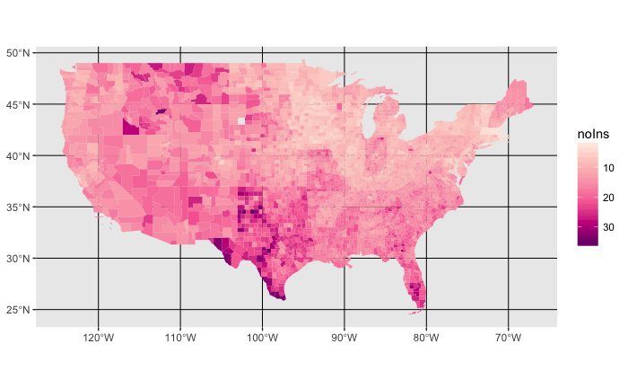

```r
noins_sf %>%
  filter(STATEFP != "02" & STATEFP != "15" & STATEFP != "72") %>%
  ggplot() +
    geom_sf(mapping = aes(fill = noIns), color = NA) +
    scale_fill_distiller(palette = "RdPu", trans = "reverse")
```

Finally, we’ll write these data to a shapefile. Before excuting this step, I add a folder to the `data/` directory. You can also do this first step manually if you’d like.

```r
dir.create(here("data", "US_HEALTH_noIns"))
```

```
'/Users/chris/GitHub/SOC5650/LectureRepos/lecture-10/assignments/lab-09/lab-09-replication/data/US_HEALTH_noIns' already exists
```

```r
st_write(noins_sf, here("data", "US_HEALTH_noIns", "US_HEALTH_noIns.shp"), delete_dsn = TRUE)
```

```
Deleting source `/Users/chris/GitHub/SOC5650/LectureRepos/lecture-10/assignments/lab-09/lab-09-replication/data/US_HEALTH_noIns/US_HEALTH_noIns.shp' using driver `ESRI Shapefile'
Writing layer `US_HEALTH_noIns' to data source `/Users/chris/GitHub/SOC5650/LectureRepos/lecture-10/assignments/lab-09/lab-09-replication/data/US_HEALTH_noIns/US_HEALTH_noIns.shp' using driver `ESRI Shapefile'
features:       3135
fields:         6
geometry type:  Multi Polygon
```